# {introverse} quick docs

`ggplot2::geom_segment()`  
**`get_help()` docs**

### Description

The [`geom_segment()`](https://ggplot2.tidyverse.org/reference/geom_segment.html) function is part of the [`{ggplot2}`](https://ggplot2.tidyverse.org/) package, which is part of the [`{tidyverse}`](https://www.tidyverse.org/).

The `geom_segment()` function is used within `{ggplot2}` plots to create line segments. Line segments have x and y start and end coordinates.

#### Required aesthetics:

- `x`: The x-coordinate for the line segment to start at
- `xend`: The x-coordinate for the line segment to end at
- `y`: The y-coordinate for the line segment to start at
- `yend`: The y-coordinate for the line segment to end at

#### Commonly used optional aesthetics:

- `color` (`colour`): The color of the line segment
- `size`: The width of the line segment
- `linetype`: The style of the line segment, where options include `"solid"`, `"dashed"`, `"dotted"`, `"dotdash"`, `"longdash"`, `"twodash"`. The default is `"solid"`.

To use this function, you need to either first load the `{ggplot2}` library, or always use the function with `ggplot2::geom_segment()` notation.

```r
# Load the library
library(ggplot2)
# Or, load the full tidyverse:
library(tidyverse)

# Or, use :: notation
ggplot2::geom_segment()
```

### Examples

Some of the examples below use the `msleep` and `carnivores` datasets. Learn more about this dataset with `get_help("msleep")` and `get_help("carnivores")`.

```r
# Show the msleep dataset with head()
head(msleep)
```

```
## # A tibble: 6 × 11
##   name  genus vore  order conservation sleep_total sleep_rem sleep_cycle awake  brainwt  bodywt
##   <chr> <chr> <chr> <chr> <chr>              <dbl>     <dbl>       <dbl> <dbl>    <dbl>   <dbl>
## 1 Owl … Aotus omni  Prim… <NA>                17         1.8      NA       7    0.0155    0.48
## 2 Moun… Aplo… herbi Rode… nt                  14.4       2.4      NA       9.6 NA         1.35
## 3 Grea… Blar… omni  Sori… lc                  14.9       2.3       0.133   9.1  0.00029   0.019
## 4 Cow   Bos   herbi Arti… domesticated         4         0.7       0.667  20    0.423   600
## 5 Thre… Brad… herbi Pilo… <NA>                14.4       2.2       0.767   9.6 NA         3.85
## 6 Nort… Call… carni Carn… vu                   8.7       1.4       0.383  15.3 NA        20.5
```

```r
# Show the carnivores dataset
carnivores
```

```
## # A tibble: 9 × 4
##   name              genus        awake brainwt
##   <chr>             <fct>        <dbl>   <dbl>
## 1 Arctic fox        Vulpes        11.5  0.0445
## 2 Cheetah           Acinonyx      11.9 NA
## 3 Dog               Canis         13.9  0.07
## 4 Gray seal         Haliochoerus  17.8  0.325
## 5 Jaguar            Panthera      13.6  0.157
## 6 Lion              Panthera      10.5 NA
## 7 Northern fur seal Callorhinus   15.3 NA
## 8 Red fox           Vulpes        14.2  0.0504
## 9 Tiger             Panthera       8.2 NA
```

```r
# Create a tibble with tibble::tribble() with values for the line segment we want to draw, and draw it!
example_tibble <- tibble::tribble(
  ~x_var, ~xend_var, ~y_var, ~yend_var,
  0,         3.5,        2,       4
)

# Look at tibble:
example_tibble
```

```
## # A tibble: 1 × 4
##   x_var xend_var y_var yend_var
##   <dbl>    <dbl> <dbl>    <dbl>
## 1     0      3.5     2        4
```

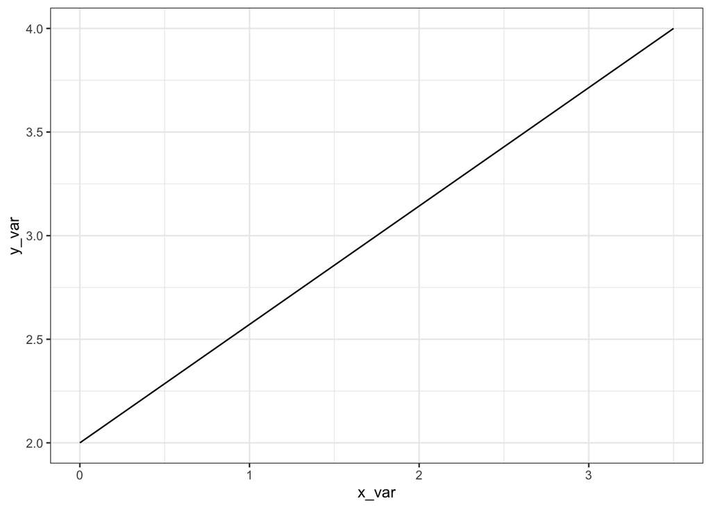

```r
ggplot(example_tibble) +
  aes(x = x_var,
      xend = xend_var,
      y = y_var,
      yend = yend_var) +
  geom_segment()
```

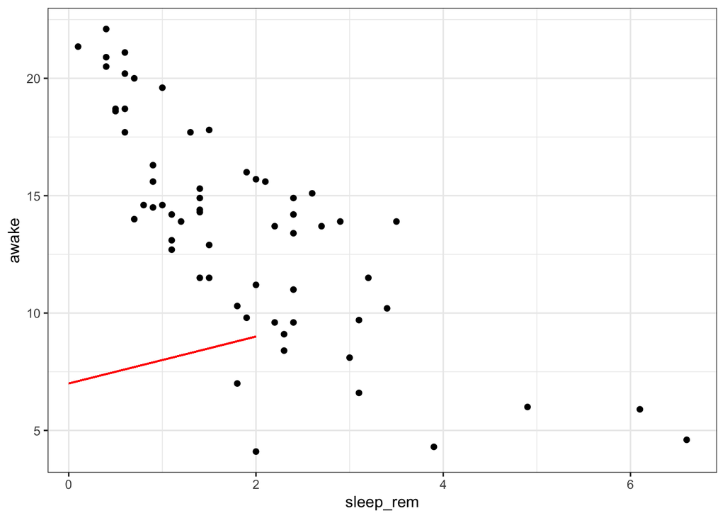

```r
# Scatterplot of awake against sleep_rem, where we add a line segment in at specified coordinates
ggplot(msleep) +
  aes(x = sleep_rem, y = awake) +
  geom_point() +
  # Add a segment:
  geom_segment(x = 0, xend = 2, y = 7, yend = 9, color = "red")
```

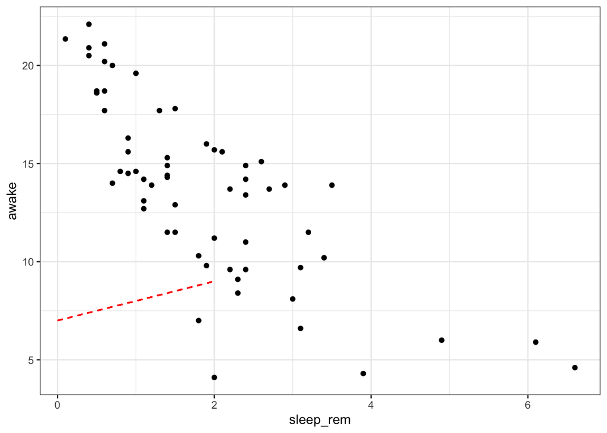

```r
# Scatterplot of awake against sleep_rem, where we add a line segment in at specified coordinates
# This example uses a different linetype
ggplot(msleep) +
  aes(x = sleep_rem, y = awake) +
  geom_point() +
  # Add a segment:
  geom_segment(x = 0, xend = 2, y = 7, yend = 9, color = "red", linetype = "dashed")
```

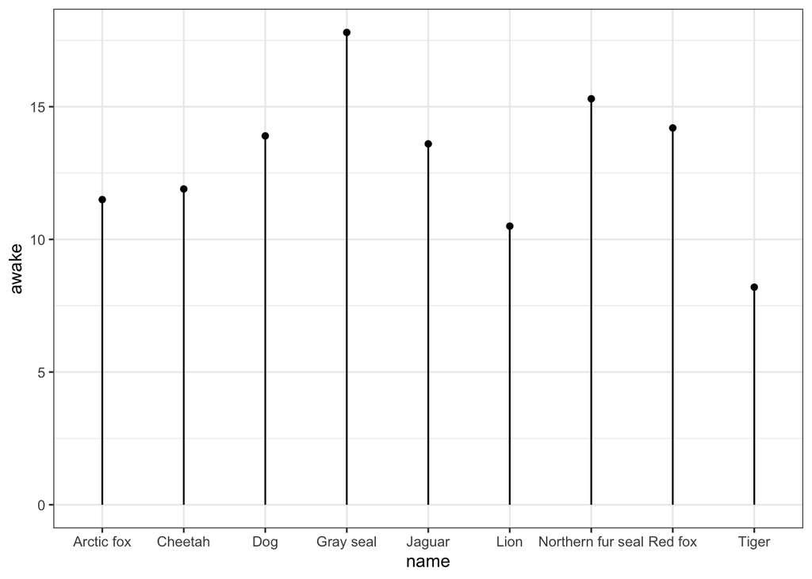

```r
# Plot the literal values of `awake` for each name in the carnivores dataset, as a lollipop plot
ggplot(carnivores) +
  aes(x = name, y = awake) +
  geom_point() +
  # To understand this, think carefully about the grammar and how data maps to these aesthetics
  geom_segment(aes(x = name,   # For a vertical line, x starts and stops at same coordinate.
                   xend = name,
                   y = 0, # y starts from 0
                   yend = awake)) # and goes to the awake value
```